# MAT651_LA2

## LAB 2: CMATH

**Date: 04-1-2024**

```python
from cmath import *
import math
import numpy as np
import sympy as sp
import matplotlib.pyplot as plt
import ipywidgets as widgets
import random
```

```python
a = 2 + 4j
a
```

```
(2+4j)
```

> Absolute of Complex Number

```python
abs(a)
```

```
4.47213595499958
```

```python
(a.real**2 + a.imag**2)**0.5
```

```
4.47213595499958
```

> Phase of Complex Number

```python
polar(a)[-1]
```

```
1.1071487177940904
```

```python
atan(a.imag/a.real)
```

```
(1.1071487177940904+0j)
```

> Polar Form of Complex Number

```python
polar(a)
```

```
(4.47213595499958, 1.1071487177940904)
```

```python
print(polar(a)[0],"e^",polar(a)[1])
```

```
4.47213595499958 e^ 1.1071487177940904
```

> WAP to print constants in cmath

```python
consts = zip(["e","inf","infj","nan","nanj","pi","tau"],[e,inf,infj,nan,nanj,pi,tau])
dict(consts)
```

```
{'e': 2.718281828459045,
 'inf': inf,
 'infj': infj,
 'nan': nan,
 'nanj': nanj,
 'pi': 3.141592653589793,
 'tau': 6.283185307179586}
```

> WAP to verify the following properties of complex numbers.
> - Commutative Addition
> - Commutative Multiplication
> - Associative Addition
> - Associative Multiplication
> - Distributive

```python
def commutativeAdd(a,b,c):
    if(a+b == b+a):
        return True
    return False
def commutativeMult(a,b,c):
    if(a*b == b*a):
        return True
    return False
def associativeAdd(a,b,c):
    if((a+b)+c == a+(b+c)):
        return True
    return False
def associativeMult(a,b,c):
    if((a*b)*c == a*(b*c)):
        return True
    return False
def distributive(a,b,c):
    if(a*(b+c) == a*b + a*c):
        return True
    return False
```

```python
a,b,c = [eval(input("Enter Number: ")) for i in range(3)]
```

```python
print("Satisfied Commutative Law of Addition" if (commutativeAdd(a,b,c)) else "Do Not Satisfy Commutative Law of Addition")
print("Satisfied Commutative Law of Multiplication" if (commutativeMult(a,b,c)) else "Do Not Satisfy Commutative Law of Multiplication")
print("Satisfied Associative Law of Addition" if (associativeAdd(a,b,c)) else "Do Not Satisfy Associative Law of Addition")
print("Satisfied Associative Law of Multiplication" if (associativeMult(a,b,c)) else "Do Not Satisfy Associative Law of Multiplication")
print("Satisfied Distributive Law" if (distributive(a,b,c)) else "Do Not Satisfy Distributive Law")
```

```
Satisfied Commutative Law of Addition
Satisfied Commutative Law of Multiplication
Satisfied Associative Law of Addition
Satisfied Associative Law of Multiplication
Satisfied Distributive Law
```

```python
funcs = [commutativeAdd,commutativeMult,associativeAdd,associativeMult,distributive]
for i in funcs:
    print("Verified" if i(a,b,c) else "Non Verified" ,"Law of", i.__name__)
```

```
Verified Law of commutativeAdd
Verified Law of commutativeMult
Verified Law of associativeAdd
Verified Law of associativeMult
Verified Law of distributive
```

> WAP to verify that the sum of two conjugate numbers is real.

```python
a = eval(input("Enter Number: "))
a_conj = a.conjugate()
conjSum = a+a_conj
print(conjSum)
"Verified" if conjSum.imag == 0 else "Not Verified"
```

```
(4+0j)
```

```
'Verified'
```

> WAP to verify that the product of conjugate numbers is real.

```python
a = eval(input("Enter Number: "))
a_conj = a.conjugate()
conjProd = a*a_conj
print(conjProd)
"Verified" if conjProd.imag == 0 else "Not Verified"
```

```
(13+0j)
```

```
'Verified'
```

> WAP to prove that $|z_{1} + z_{1}| \leq |z_{1}| + |z_{1}|$.

```python
a,b = [eval(input("Enter Number: ")) for i in range(2)]
True if(abs(a+b) <= abs(a)+abs(b)) else False
```

```
True
```

> WAP to verify that, if the sum and product of two complex numbers is real, then they are conjugates of each other.

```python
a,b = [eval(input("Enter Number: ")) for i in range(2)]
```

```python
if((a*b).imag == 0 and (a+b).imag == 0):
    print("Numbers are Conjugate")
else:
    print("Numbers are Not Conjugate")
print(a.conjugate() == b)
```

```
Numbers are Not Conjugate
False
```

> WAP to verify the Eulers formula  
> $\quad \quad e^{i\theta} = \cos \theta + i \sin \theta$

```python
a = eval(input("Enter complex number(arg,amp)$"))
#print(a[1]*exp(a[0]*1j),a[1]*(cos(a[0]) + 1j*sin(a[0])))
True if(a[1]*exp(a[0]*1j) == a[1]*(cos(a[0]) + 1j*sin(a[0]))) else False
```

```
True
```

> WAP to plot the given set of complex numbers.

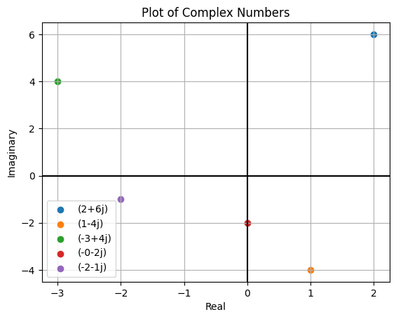

```python
z = eval(input("Enter list of complex numbers:"))
def plotComplex(z,show = True,legend = True):
    f = plt.figure()
    for i in z:
        plt.scatter(i.real,i.imag)
    if(legend):
        plt.legend(z)
    plt.grid()
    plt.axhline(color = "black")
    plt.axvline(color = "black")
    plt.xlabel("Real")
    plt.ylabel("Imaginary")
    plt.title("Plot of Complex Numbers")
    if show:
        plt.show()
    return f
#[2+6j, 1-4j,-3+4j, -2j, -2-1j]
plotComplex(z);
```

> WAP to find the furthest point from the origin

```
Maximum Distance=  (7-7j)
```

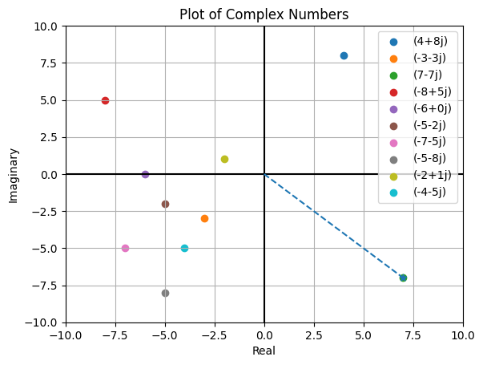

```python
#z = eval(input("Enter list of complex numbers:"));
z = [complex(random.randint(-8,8),random.randint(-8,8)) for i in range(10)]
maxz = list(map(lambda z: abs(z),z))
maxz = maxz.index(max(maxz))
maxz = z[maxz]
print("Maximum Distance= ",maxz)
f = plotComplex(z,False)
plt.xlim(-10,10)
plt.ylim(-10,10)
plt.figure(f)
plt.scatter(maxz.real,maxz.imag,marker = "*",label = "Maximum")
plt.plot([0,maxz.real],[0,maxz.imag],linestyle = "--")
#plt.legend()
plt.show()
```

```python
z = (3 - 1j)/(2+3j) - (2-2j)/(1-5j)
z
```

```
(-0.23076923076923073-1.1538461538461537j)
```

```python
def unityRoots(n = 1):
    return np.roots([1]+ [0]*(n-1) + [1])
    #x = sp.Symbol("x")
    #return sp.solve(sp.Eq(x**n,1),x)
unityRoots(4)
```

```
array([-0.70710678+0.70710678j, -0.70710678-0.70710678j,
        0.70710678+0.70710678j,  0.70710678-0.70710678j])
```

```python
def plotRoots(n):
    roots = unityRoots(n)
    f = plt.figure()
    plt.axhline(color = "black")
    plt.axvline(color = "black")
    plt.grid(which="both")
    plt.xlim(-1.2,1.2)
    plt.ylim(-1.2,1.2)
    for i in roots:
        i = complex(i)
        #pll.polar(1,phase(i))
        plt.scatter(i.real,i.imag)
    plt.title(f"n = {n}")
    plt.show()
widgets.interactive(plotRoots,n = (1,10))
```

[output not shown]

**Date: 17-01-24**

**LIMITS OF COMPLEX FUNCTION**

```python
def plotF(f:"Callable",x_lim):
    X = np.linspace(-x_lim,x_lim,100)
    plt.plot(X,[f(i) for i in X])
    plt.grid()
    plt.axhline(color = "black")
    plt.axvline(color = "black")
    plt.show()
```

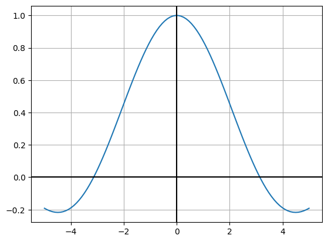

```python
def f(x):
    return np.sin(x)/x
plotF(f,5)
```

```python
def getLimit(f:"sympy.Function",z = sp.Symbol("z"), z0 = 0):
    lim = sp.limit(f,z,z0)
    return complex(lim.simplify())
```

```python
getLimit("sin(z)/z",z0 = 1+1j)
```

```
(0.9667107481003567-0.3317468333156206j)
```

**Date: 18-01-24**

**LIMIT OF A COMPLEX SEQUENCE**

```python
def limitingPoints(f:"sympy.Function",z = sp.Symbol("z"), zStart = 1,zLimit = 0):
    func = sp.lambdify(z,f,"numpy")
    points = np.linspace(zStart,zLimit,50)[:-1]
    fig = plotComplex([func(i) for i in points],show=False,legend=False)
    limit = getLimit(f,z0 = zLimit)
    plt.scatter(limit.real,limit.imag,marker = '*',s = 50,label ="Limiting Point")
    plt.scatter([i.real for i in points],[i.imag for i in points],label = "Limit Input")
    plt.legend(title = f"Limit = {limit}")
    plt.title(f"{f}")
    plt.show()
    return
```

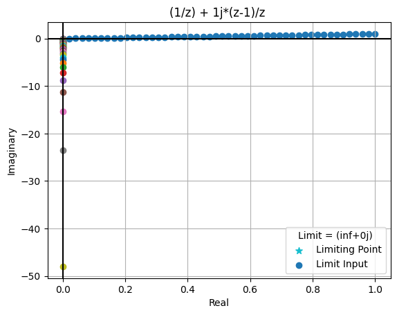

```python
limitingPoints("(1/z) + 1j*(z-1)/z ",zStart=complex(1,1),zLimit=0)
```

> $i \dfrac{n^2}{n^2 + 1}$

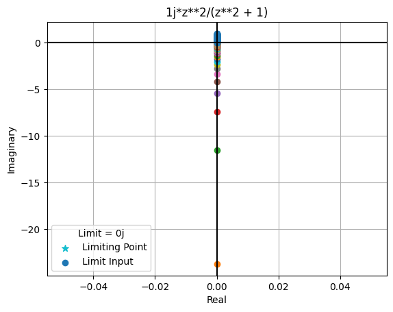

```python
limitingPoints("1j*z**2/(z**2 + 1)",zStart=1j,zLimit=0)
```

> $(1+\dfrac{4}{z})^z + i\dfrac{7z}{z+4}$

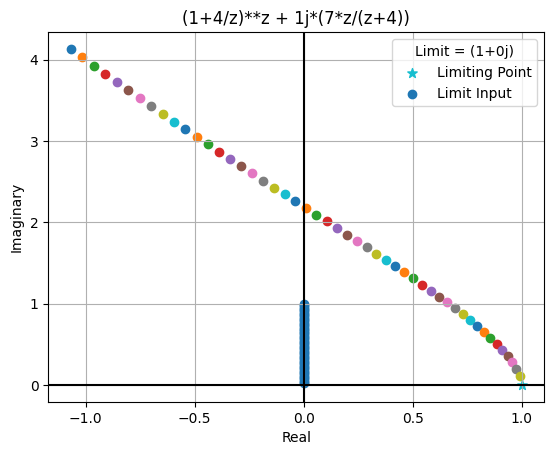

```python
limitingPoints("(1+4/z)**z + 1j*(7*z/(z+4))",zStart=1j,zLimit=0)
```

> $\sqrt(z+1) - i\sqrt(z+3)$

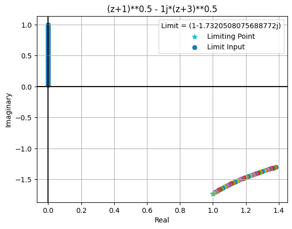

```python
limitingPoints("(z+1)**0.5 - 1j*(z+3)**0.5",zStart=1j,zLimit=0)
```

> $\dfrac{1}{2}^z + z\dfrac{1-i}{2}$

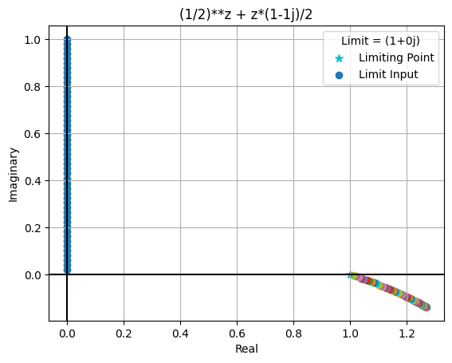

```python
limitingPoints("(1/2)**z + z*(1-1j)/2",zStart=1j,zLimit=0)
```

> $z\dfrac{(3 + 4i)^2}{5}$

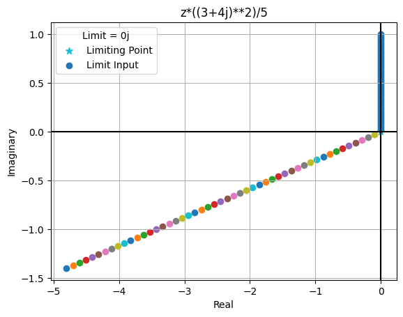

```python
limitingPoints("z*((3+4j)**2)/5",zStart=1j,zLimit=0)
```

> $ (3 + \dfrac{5}{z})^{z} + i\dfrac{5+z}{z}$

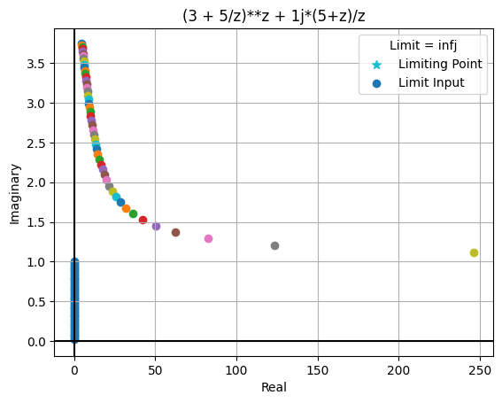

```python
limitingPoints("(3 + 5/z)**z + 1j*(5+z)/z",zStart=1j,zLimit=0)
```

**Asynchronous Assignment**  
**Date: 22-01-24**

> WAP to find and plot the given limits.

> $\dfrac{1}{z} + i\dfrac{z-1}{z}$

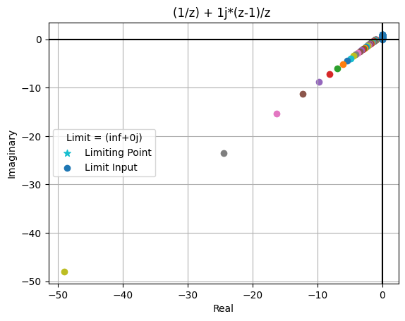

```python
limitingPoints("(1/z) + 1j*(z-1)/z ",zStart=1j,zLimit=0)
```

> $i\dfrac{z^2}{z^2 + 1}$

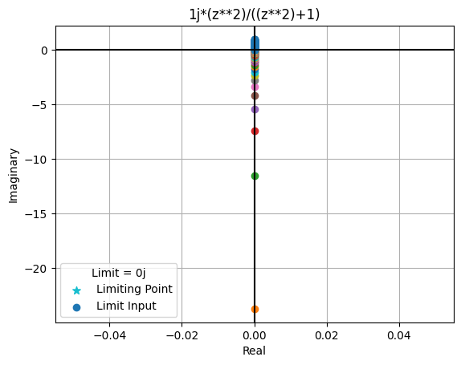

```python
limitingPoints("1j*(z**2)/((z**2)+1)",zStart=1j,zLimit=0)
```

> $(-1)^z + i\dfrac{z+1}{z}$

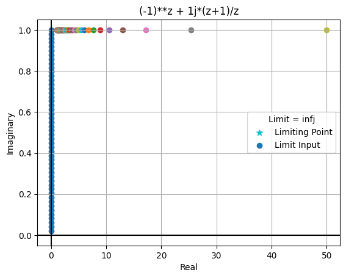

```python
limitingPoints("(-1)**z + 1j*(z+1)/z",zStart=1j,zLimit=0)
```

> $(1 + \dfrac{4}{z})^z + i\dfrac{7z}{z+4}$

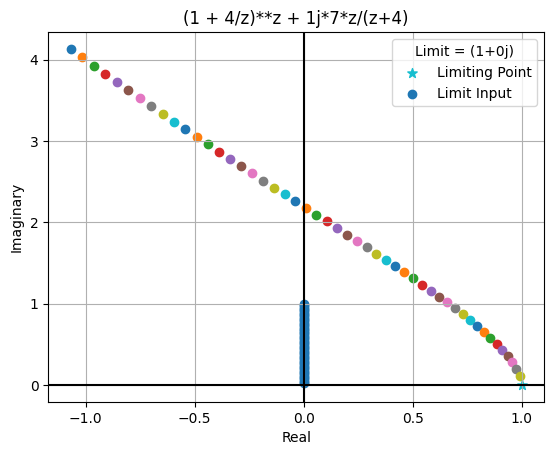

```python
limitingPoints("(1 + 4/z)**z + 1j*7*z/(z+4)",zStart=1j,zLimit=0)
```

> $10\dfrac{\sin 3z}{z} + i\dfrac{\sin z}{z}$

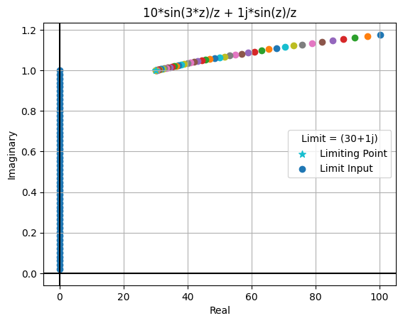

```python
limitingPoints("10*sin(3*z)/z + 1j*sin(z)/z",zStart=1j,zLimit=0)
```

> $1 + z^\dfrac{1}{z}$

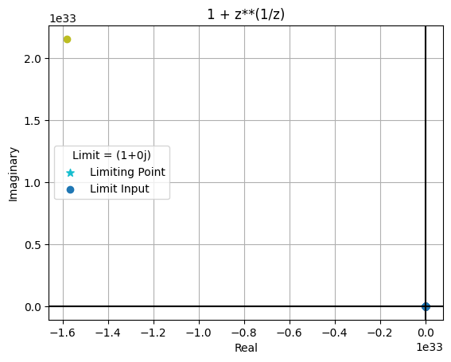

```python
limitingPoints("1 + z**(1/z)",zStart=1j,zLimit=0)
```

> WAP to verify using examples that, lim(czn) = c lim(zn)

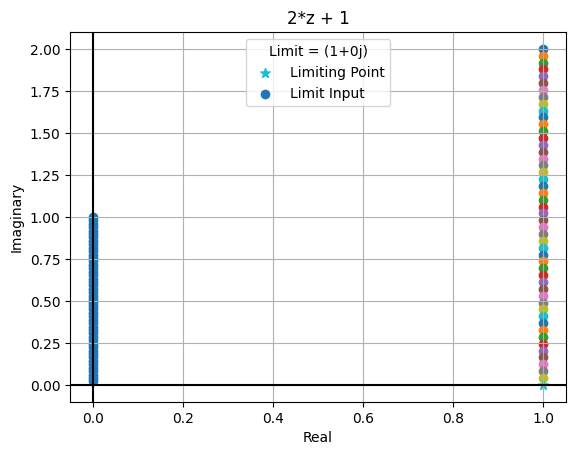

```python
# zn = (2z+1)
limitingPoints("2*z + 1",zStart=1j,zLimit=0)
```

```python
# c = 2
# 2*1 = 2
```

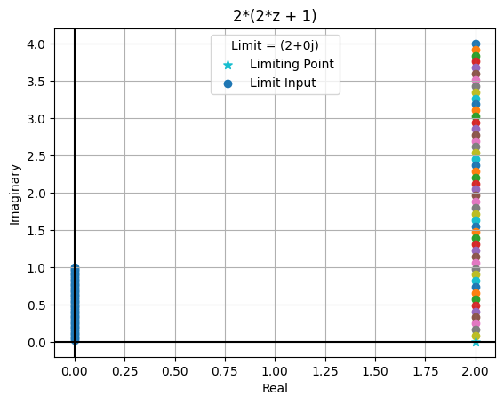

```python
limitingPoints("2*(2*z + 1)",zStart=1j,zLimit=0)
```

**Asynchronous Assignment**  
**Date: 24-01-24**

```python
z = [3 + 7j, 18 - 32j, -5/3 + 1j*(2**0.5), (2**0.5)/2 - 1j/2, 3j]
z
```

```
[(3+7j),
 (18-32j),
 (-1.6666666666666667+1.4142135623730951j),
 (0.7071067811865476-0.5j),
 3j]
```

> Polar Form

```python
dict(zip(z,[(round(np.abs(i),3),round(np.angle(i),3)) for i in z]))
```

```
{(3+7j): (7.616, 1.166),
 (18-32j): (36.715, -1.058),
 (-1.6666666666666667+1.4142135623730951j): (2.186, 2.438),
 (0.7071067811865476-0.5j): (0.866, -0.615),
 3j: (3.0, 1.571)}
```

> Rectangular Form

```python
dict(zip(z,[(i.real,i.imag) for i in z]))
```

```
{(3+7j): (3.0, 7.0),
 (18-32j): (18.0, -32.0),
 (-1.6666666666666667+1.4142135623730951j): (-1.6666666666666667,
  1.4142135623730951),
 (0.7071067811865476-0.5j): (0.7071067811865476, -0.5),
 3j: (0.0, 3.0)}
```

> Absolute Value

```python
dict(zip(z,[round(np.abs(i),3) for i in z]))
```

```
{(3+7j): 7.616,
 (18-32j): 36.715,
 (-1.6666666666666667+1.4142135623730951j): 2.186,
 (0.7071067811865476-0.5j): 0.866,
 3j: 3.0}
```

> Argument

```python
dict(zip(z,[round(np.angle(i),3) for i in z]))
```

```
{(3+7j): 1.166,
 (18-32j): -1.058,
 (-1.6666666666666667+1.4142135623730951j): 2.438,
 (0.7071067811865476-0.5j): -0.615,
 3j: 1.571}
```

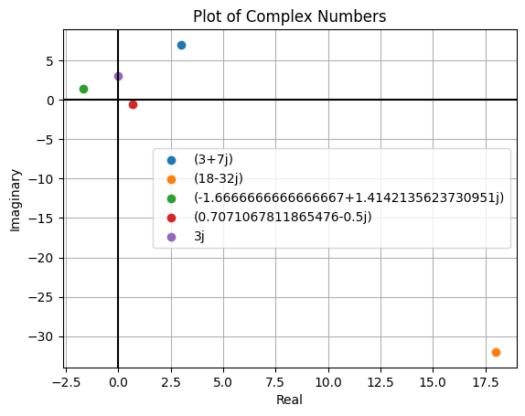

```python
plotComplex(z);
```

> Verify Eulers Formula

```python
for i in z:
    print(np.round(i,3) == np.round(np.abs(i)*(np.cos(np.angle(i)) + 1j*np.sin(np.angle(i))),3))
```

```
True
True
True
True
True
```

> Plotting any two of the numbers

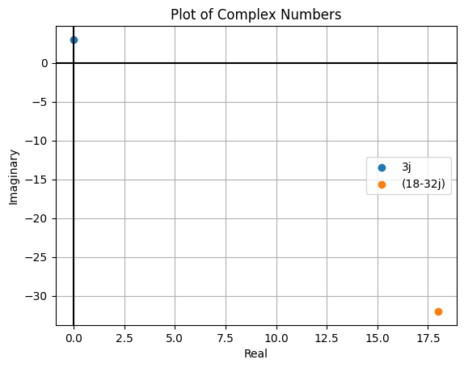

```python
plotComplex(random.choices(z,k = 2));
```

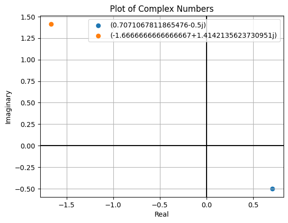

```python
plotComplex(random.choices(z,k = 2));
```

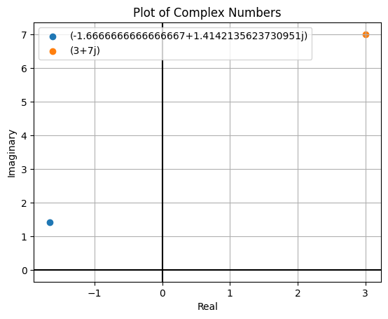

```python
plotComplex(random.choices(z,k = 2));
```